# Chapter 4: Visualizing Data with Matplotlib

**Goals**

- Understand the basic syntax of matplotlib
- Learn to produce and export high-quality figures with specific dimensions
- Learn about the benefits of a custom plotter module and how to create one

## 4.1 Introduction and Motivation

Handling and manipulating data is important. However, the human brain is not made to understand multidimensional arrays and directly extract the relevant information from them. Therefore, **visualizing** data in a suitable way is crucial! Python provides nearly unlimited capabilities with the `matplotlib` package.

There is no nice way of saying it: Getting started with plotting data from code (in Python) is both frustrating and time-consuming. The main reason is that you (probably) are more used to working with a graphical user interface (GUI) like e.g. MS Excel or Origin. However, you will get used to it and ultimately become faster (or at least equally fast) at some point. Simultaneously, plotting with Python offers you multiple other benefits:

- **All in one place**: You don't have to export your data from Python, then import it again into another software to generate your plots.
- **Automatization**: If your goal is to produce a single plot once and be done with it, sure, use a software with a GUI. However, most of the time, this will not be the case! For example in your Bachelor Thesis you produce similar data for different parameter settings and need to visualize all of them. The code for plotting the data remains the same, you just need to provide different data. This means, that you can produce identical looking plots with just a single click.
- **Flexibility**: Assume you have 10 Figures in your Bachelor Thesis and 1 day prior to the deadline your supervisor mentions that you should capitalize the axis titles. Well.. in your GUI, you will have to go through each of them, and re-export them individually. In Python, you can simples search and replace the respective strings and just run your code again (a single click).
- **Consistency**: Your graphs will look consistent because they are produced by code and not by drag and drop of boxes with your mouse.
- **LateX**: If you use LateX for writing your documents (as you absolutely should by the way), the integration is just perfect.

Obviously, I am biased towards plotting in Python. But believe me when I say that it payed off for me over the course of my studies and PhD.

In this notebook, we will look at some basics, some formatting syntax and some example plots. For more examples and requirements that are specific to your project and data, you **need** to ask the internet. For every problem, there is a stackoverflow solution. Plus, ChatGPT really knows it's stuff!

As with all other packages, you have to import matplotlib first. Similar to numpy, a standard import name `plt` has been established in the community. Therefore, the *"standard"* way of importing matplotlib is performed by the following command:

```python
import matplotlib.pyplot as plt
```

## 4.2 The `matplotlib` Objects `figure` and `axes`

The first step in visualizing your data is creating a `figure` and `axes` object. For this we use the syntax `fig, ax = plt.subplots( )`. Let's keep it simple for now and do not pass any additional arguments to this method. See the [documentaion](https://matplotlib.org/stable/api/_as_gen/matplotlib.pyplot.subplots.html) for further information.

- A figure `fig` is a Figure object. Think of the *matplotlib-figure-canvas* as a white sheet of paper (with a certain width and height) on which you draw your coordinate system.
- An axes `ax` is an Axes object. The `ax` variable stores all information of your data that you want to draw in your coordinate system, which consists of one `x`- and `y`-axis. There can be **multiple datasets** on one single axes.

We now add datasets to the `ax` object by calling the desired methods. Some very important axes methods are listed below. There are many more and you can even produce 3D plots. A good place to get a sense of the possibilities is the [example page of matplotlib](https://matplotlib.org/stable/plot_types/index.html).

- `ax.plot(x,y)`: The default way of visualizing `x` and `y` data-pairs (2D plot). By default, matplotlib plots a **line**
- `ax.scatter(x,y)`: 2D plot of `x` and `y` data-pairs, only plotting **markers**
- `ax.bar(x,y)`: 2D **bar** plot. Syntax is a bit more special at times.
- `ax.errorbar(x,y,yerr,xerr)`: 2D scatter plot but also plot error bar.
- `ax.text(x,y,s)`: Add text to a specific point in the plot. See the [documentation](https://matplotlib.org/stable/api/_as_gen/matplotlib.axes.Axes.text.html) for more info.

Let's create our first figure and axes and plot 2 data-sets on the axes. One connected with lines, the other only showing markers:

```
fig has datatype <class 'matplotlib.figure.Figure'>
ax has datatype <class 'matplotlib.axes._axes.Axes'>
```

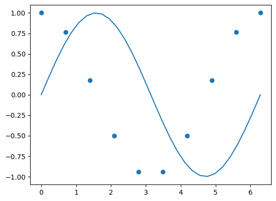

```python
import numpy as np
import matplotlib.pyplot as plt

# Set up the figure and axes and print the type for our personal interest
fig, ax = plt.subplots()

print('fig has datatype', type(fig))
print('ax has datatype', type(ax))

# Let's create some data
x1 = np.linspace(0, 2*np.pi, 30)
x2 = np.linspace(0, 2*np.pi, 10)

y1 = np.sin(x1)
y2 = np.cos(x2)

# Plot (x1,y1) as line plot
ax.plot(x1, y1)

# Plot (x2,y2) as scatter plot on the same axes!
ax.scatter(x2, y2)
```

## 4.3 Customizing a Plot

Nice! We visualized the data stored in `(x1, y1)` and `(x2, y2)`! However, this plot is not really nice to look at and not at all publication ready. Luckily, we can **customize** nearly all aspects of it! Let's differentiate between **data-set customization** (e.g. customizing each *line* in an axes) and **axes customization** (changing global properties of the axes).

### 4.3.1 Customizing an Individual Data-Set

The best way of changing the properties of a specific data-set is directly during the plotting procedure (e.g. during `plt.plot()`). We do this by passing certain keyword arguments to the method. Each method supports different arguments, so ultimately you will have to look into the documentation (or simple google your problem). Some very important arguments for `plt.plot()` include the following:

- `color`: There are various ways to define a color! The simplest one is to provide one of the many *named colors* (e.g. `'k'` for black (key) or `'r'` for red). But you can also define RGB values etc. See [this page](https://matplotlib.org/stable/tutorials/colors/colors.html) for more information.
- `linestyle`: Defines the type of line to be used. The options are `['-','--','-.',':']` (feel free to try them out!)
- `marker`: Defines the marker type to be used. See the [list of markers](https://matplotlib.org/stable/api/markers_api.html) for reference. When you use `plt.plot()`, the default is `'none'` (only line).
- `markeredgecolor` (`plt.plot()`) or `edgecolor` (`plt.scatter()`): Defines the color of the marker edge. See `color` above.
- `label`: This does not change anything immediately visually, but labels a data-set that can make printing a legend easier. This keyword takes a `str`.
- `zorder`: Again, no visual change. `zorder` defines which layer is on top of each other (if plots happen to overlap). The higher the number the higher up.

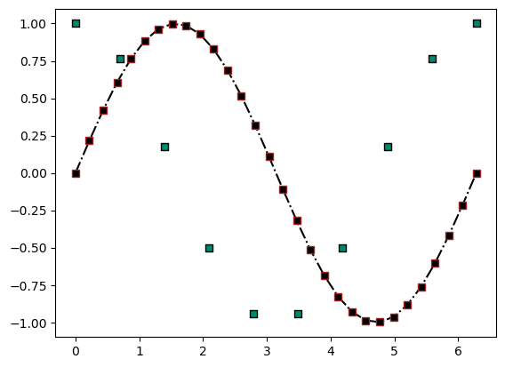

```python
# Let's repeat this and make it a bit nicer
fig, ax = plt.subplots()
x1 = np.linspace(0, 2*np.pi, 30)
x2 = np.linspace(0, 2*np.pi, 10)
y1 = np.sin(x1)
y2 = np.cos(x2)

# Plot (x1,y1) as line plot
ax.plot(x1, y1, color='k', linestyle='-.', marker='s', markeredgecolor='#a22223', label='sin(x)', zorder=3)

# Plot (x2,y2) as scatter plot on the same axes!
ax.scatter(x2, y2, color = '#00876C', marker='s', edgecolor='k', label='cos(x)', zorder=2)
```

### 4.3.2 Customizing the Entire Axes

We are slowly getting there! Obviously, there is still work to be done, especially with regard to the overall layout of the plot. After plotting the data as shown above, we then adjust some specific axes properties. [Here](https://matplotlib.org/stable/users/explain/quick_start.html#parts-of-a-figure), you can find a nice overview of the most important ones! Some very important functions include the following:

- `ax.set_xlabel()`, `ax.set_ylabel()`: Takes a `str` argument and puts it on the x- and y-axis respectively.  
  ***Note:*** Matplotlib supports LateX formatting! So to use greek symbols, you can simple write something like `$\phi$`. (See [this page](https://www.overleaf.com/learn/latex/List_of_Greek_letters_and_math_symbols) for an overview)
- `ax.set_title()`: Sets the title of the figure. For your scientific work, you normally want to avoid doing that and rather use the caption.
- `ax.set_xlim()`, `ax.set_ylim()`: Takes a `list` of two values and defines the limits of the respective axis.
- `ax.set_xscale()`, `ax.set_yscale()`: Use either `'lin'` or `'log'` for linear or logarithmic axis scaling. The default is linear.
- `ax.legend()`: Activates the legend. This method has a lot of functionality that can be researched [here](https://matplotlib.org/stable/api/_as_gen/matplotlib.axes.Axes.legend.html)
- `ax.grid()`: Activates the grid. See the [documentation](https://matplotlib.org/stable/api/_as_gen/matplotlib.axes.Axes.grid.html) for more info.

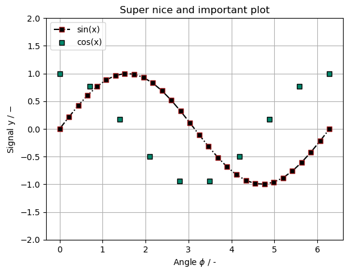

```python
# Let's repeat this and make it a bit nicer
fig, ax = plt.subplots()
x1 = np.linspace(0, 2*np.pi, 30)
x2 = np.linspace(0, 2*np.pi, 10)
y1 = np.sin(x1)
y2 = np.cos(x2)
ax.plot(x1, y1, color='k', linestyle='-.', marker='s', markeredgecolor='#a22223', label='sin(x)', zorder=3)
ax.scatter(x2, y2, color = '#00876C', marker='s', edgecolor='k', label='cos(x)', zorder=2)

# Let's customize some axes properties
ax.set_xlabel('Angle $\phi$ / -')
ax.set_ylabel('Signal y / $-$')
ax.set_title('Super nice and important plot')
ax.set_ylim([-2, 2])
# ax.set_xscale('log') # Try this if you want. Does not make sense here though :)
ax.legend(loc='upper left')
ax.grid(True)
```

### 4.3.3 Default Figure Parameters (`plt.rc` and `plt.rcParams`)

Other essential parameters include the size of the figure and the fonts. You can define them individually for each axis, legend, title etc., but this has a risk of being inconsistent. Another way of doing it is to re-define the global default parameters before actually plotting anything. This makes the changes global and applies them to every following plot. You use the syntax `plt.rc(GROUP, **kwargs)` and for each group `GROUP` provide the desired keyword - argument pairs. Some interesting groups and keywords include

- `'font', family=FF`. For `FF` you can provide any font that is installed (e.g. `'arial'`).
- `'axes', labelsize=LS`. Provide the labelsize in pt.
- `'legend', fontsize=FS`. Provide the fontize in pt.
- `'figure', figsize=FigS`. Provide the size of the figure as list with two numeric values `[x-dim, y-dim]`. `x-dim` and `y-dim` define the absolute size of the figure in inches!  
  ***Note:*** 1 inch = 2.54 cm. Therefore if you want specific dimensions in cm, divide the values by 2.54!

Setting the figure and font sizes is super satisfying when writing e.g. your Bachelor Thesis. You can make it, so your figure is **exactly** the width of you text and then define the fontsize to be **exactly** the font and size of your document. Never stress about the scaling again!

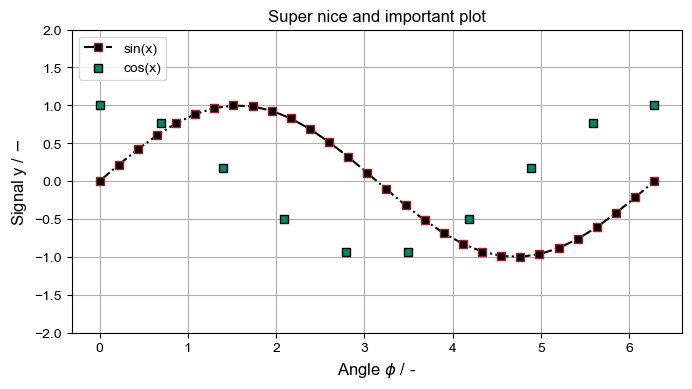

```python
# Let's define some default values
plt.rc('font', family='arial')
plt.rc('axes', labelsize=12)
plt.rc('legend', fontsize=10)
size = [20/2.54, 10/2.54] # Create a 20cm by 10cm figure!
plt.rc('figure', figsize=size)

# Let's repeat this and make it a bit nicer
fig, ax = plt.subplots()
x1 = np.linspace(0, 2*np.pi, 30)
x2 = np.linspace(0, 2*np.pi, 10)
y1 = np.sin(x1)
y2 = np.cos(x2)
ax.plot(x1, y1, color='k', linestyle='-.', marker='s', markeredgecolor='#a22223', label='sin(x)', zorder=3)
ax.scatter(x2, y2, color = '#00876C', marker='s', edgecolor='k', label='cos(x)', zorder=2)
ax.set_xlabel('Angle $\phi$ / -')
ax.set_ylabel('Signal y / $-$')
ax.set_title('Super nice and important plot')
ax.set_ylim([-2, 2])
ax.legend(loc='upper left')
ax.grid(True)
```

## 4.4 Exporting the Plot

Now that you have created the plot, you obviously want to export it to a specific file. `matplotlib` is super flexible in this regard and lets you customize various options.

- Before exporting, you may want to use the method `plt.tight_layout()` in order to remove some unwanted whitespace.
- Use the method `plt.savefig(EXPSTR, dpi=DPI)` for exporting the plot. Specify the following arguments:
  - The `EXPSTR` is a `str` value defining the name of the produced file. At the same time you define the file format! E.g. `'test.png'` produces a .png and `'test.pdf'` a .pdf file.
  - The `DPI` setting defines the resolution of the file (in dots per inch). 300 is a good value.

The correct export format depends on the word processor you use. Generally, there are both **raster graphics** and **vector graphics**. Raster graphic formats like .png and .jpg store information for each pixel of the 2D raster. An actual *image* is a good example for this. Here, the resolution is important! Vector graphics work differently: They store mathematical information about how and where to draw all lines and elements. The resolution does not matter at all! Typical formats include .svg and .pdf. If you have the choice, **always** prefer vector graphics, as they will never be blurred. You can zoom in a much as you want, the image will always be crisp, as it is simple re-calculated. MS Office often only supports raster graphics, while LateX happily accepts vector graphic formats ;)

Let's export our plot in various formats and resolutions. Try two things:

1. Open up all of the files and zoom in really far
2. Investigate the properties of the .pdf file and check the dimensions of the plot

```python
# Let's repeat the plotting process
plt.rc('figure', figsize=[20/2.54, 10/2.54])
fig, ax = plt.subplots()
x1 = np.linspace(0, 2*np.pi, 30)
x2 = np.linspace(0, 2*np.pi, 10)
y1 = np.sin(x1)
y2 = np.cos(x2)
ax.plot(x1, y1, color='k', linestyle='-.', marker='s', markeredgecolor='#a22223', label='sin(x)', zorder=3)
ax.scatter(x2, y2, color = '#00876C', marker='s', edgecolor='k', label='cos(x)', zorder=2)
ax.set_xlabel('Angle $\phi$ / -')
ax.set_ylabel('Signal y / $-$')
ax.set_title('Super nice and important plot')
ax.set_ylim([-2, 2])
ax.legend(loc='upper left')
ax.grid(True)

# Apply tight layout
plt.tight_layout()

# Export the plot in both .png and .pdf format. Make sure that a folder named export exists!
plt.savefig('export/niceplot_png_dpi50.png', dpi=50)
plt.savefig('export/niceplot_png_dpi300.png', dpi=300)
plt.savefig('export/niceplot_pdf.pdf')
```

## 4.5 Create a Custom Plotter Module

The idea behind a custom plotter module is to centralize all of your default options and to make your plots consistent. Additionally, it lowers both the required thinking and coding when producing a plot and let's you quickly visualize data that still looks good!

### 4.5.1 Create a Custom Color Palette

When you work on a large project, re-using the same colors makes your plots look coherent and professional. Most employers have some *color design guidelines* that define specific colors that you should use. For the KIT Karlsruhe these look like this:

[output not shown]

Instead of re-defining these colors in every plot or - god forbid - memorizing the hex-codes, we will create a module that allows us to simply import these colors!

1. Inside your working directory `.\`, create a folder to store your modules, e.g. called `mod`
2. Inside `.\mod\` create a python file called `my_plotter.py`
3. Add the following code to the file:

```python
transparent = (1.0, 1.0, 1.0, 0.0)
white = (1.0, 1.0, 1.0)
black='#000000'
gray='#404040'
green='#009682'
blue='#4664aa'
red='#a22223'
yellow='#fce500'
orange='#df9b1b'
lightgreen='#8cb63c'
purple='#a3107c'
brown='#a7822e'
cyan='#23a1e0'
```

4. In any `main.py` in your working directory you can now import the `my_plotter` module in the beginning with the line with the command `import mod.my_plotter as pt` and later use the respective colors e.g. with `pt.red`.

### 4.5.2 Create a Custom Init Function

Remember when we defined the default `matplotlib` parameters? Instead of doing this every time you want to plot something, you can write a function to do this for you. Look at the `init_plot()` function below and understand what the respective arguments do. Then add this function to your `my_plotter` module!

```python
def init_plot(scl_a4=1, page_lnewdth_cm=16.5, scl=1, fnt='arial',figsze=[6.4,4.8], mrksze=6,
              lnewdth=1.5, fontsize = 10, labelfontsize=9, tickfontsize=8):

    # --- Initialize defaults ---
    plt.rcdefaults()

    # --- Calculate figure size in inches ---
    # scl_a4=2: Half page figure
    if scl_a4==2:
            fac=scl*page_lnewdth_cm/(2.54*figsze[0]*2) #2.54: cm --> inch
            figsze=[figsze[0]*fac,figsze[1]*fac]

    # scl_a4=1: Full page figure
    elif scl_a4==1:
            fac=scl*page_lnewdth_cm/(2.54*figsze[0]) #2.54: cm --> inch
            figsze=[figsze[0]*fac,figsze[1]*fac]

    # --- Adjust legend ---
    plt.rc('legend',fontsize=fontsize*scl,fancybox=True, shadow=False, edgecolor='k', handletextpad=0.2, handlelength=1,
            borderpad=0.2, labelspacing=0.2, columnspacing=0.2)

    # --- General plot setup ---
    plt.rc('mathtext', fontset='cm')
    plt.rc('font', family=fnt)
    plt.rc('xtick', labelsize=tickfontsize*scl)
    plt.rc('ytick', labelsize=tickfontsize*scl)
    plt.rc('axes', labelsize=labelfontsize*scl, linewidth=0.5*scl, titlesize=labelfontsize*scl)
    plt.rc('legend', fontsize=fontsize*scl)
    plt.rc('axes', axisbelow=True) # Grid lines in Background
    plt.rcParams['lines.markersize']=mrksze
    plt.rcParams['hatch.linewidth']=lnewdth/2
    plt.rcParams['lines.linewidth']=lnewdth
    plt.rcParams['figure.figsize']=figsze
```

### 4.5.3 Applying your Custom Plotter Module

Now that you have you custom module `my_plotter` saved in the `./mod` folder, we can use it to create consistently good looking plots in matplotlib with minimal coding work! Also look at how we use the defined colors with e.g. `pt.green`!

```python
# Import your module (and matplotlib if necessary)
import mod.my_plotter as pt

# Initialize plot
pt.init_plot(scl_a4=2, page_lnewdth_cm=25, scl=1, fnt='Comic Sans MS', mrksze=12, fontsize = 12, labelfontsize=15, tickfontsize=3)

# Example
x1 = np.linspace(0, 2*np.pi, 30)
x2 = np.linspace(0, 2*np.pi, 10)
y1 = np.sin(x1)
y2 = np.cos(x2)
fig, ax = plt.subplots()
ax.plot(x1, y1, color='k', linestyle='-.', marker='s', markeredgecolor=pt.red, label='sin(x)', zorder=3)
ax.scatter(x2, y2, color = pt.green, marker='s', edgecolor='k', label='cos(x)', zorder=2)
ax.set_xlabel('Angle $\phi$ / -')
ax.set_ylabel('Signal y / $-$')
ax.set_title('Super nice and important plot')
ax.set_ylim([-2, 2])
ax.legend(loc='upper left')
ax.grid(True)
```

[output not shown]